# Plotting_Data_KDE

This is an example of a kernel density estimation plot (KDE) and jointplot() with seaborn

```python
import matplotlib.pyplot as plt
import pandas as pd
import seaborn as sns
import numpy as np
import scipy.stats as ss
import random

sns.set_style('white')

%matplotlib inline
```

```python
movie_df = pd.read_csv('imdb.csv', delimiter='\t')
movie_df.head()
```

|  | Title | Year | Rating | Votes |
| --- | --- | --- | --- | --- |
| 0 | !Next? | 1994 | 5.4 | 5 |
| 1 | #1 Single | 2006 | 6.1 | 61 |
| 2 | #7DaysLater | 2013 | 7.1 | 14 |
| 3 | #Bikerlive | 2014 | 6.8 | 11 |
| 4 | #ByMySide | 2012 | 5.5 | 13 |

We can plot a histogram and KDE using pandas:

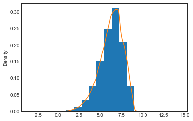

```python
movie_df['Rating'].hist(bins=10, normed=True)
movie_df['Rating'].plot(kind='kde')
```

Or using seaborn:

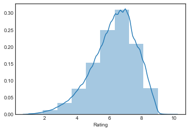

```python
sns.distplot(movie_df['Rating'], bins=10)
```

We can get a random sample using pandas' [**`sample()`**](http://pandas.pydata.org/pandas-docs/stable/generated/pandas.DataFrame.sample.html) function. The [**`kdeplot()`**](https://stanford.edu/~mwaskom/software/seaborn/generated/seaborn.kdeplot.html) function in seaborn provides many options (like kernel types) to do KDE.

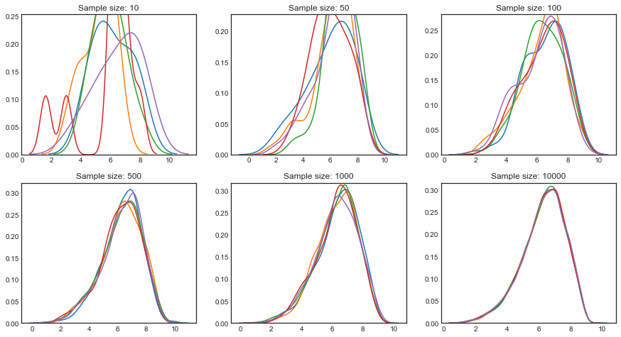

```python
f = plt.figure(figsize=(15,8))
plt.xlim(0, 10)

sample_sizes = [10, 50, 100, 500, 1000, 10000]
for i, N in enumerate(sample_sizes, 1):
    plt.subplot(2,3,i)
    plt.title("Sample size: {}".format(N))
    for j in range(5):
        s = movie_df['Rating'].sample(N)
        sns.kdeplot(s, kernel='gau', legend=False)
```

This is an example using [Anscombe's quartet](https://en.wikipedia.org/wiki/Anscombe%27s_quartet) We'll plot four datasets and do linear regression, which can be done with scipy's [**`linregress()`**](http://docs.scipy.org/doc/scipy/reference/generated/scipy.stats.linregress.html) function.

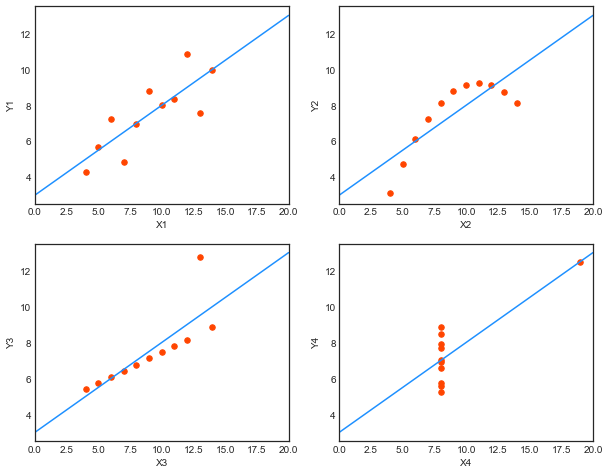

```python
X1 = [10.0, 8.0,  13.0,  9.0,  11.0, 14.0, 6.0,  4.0,  12.0,  7.0,  5.0]
Y1 = [8.04, 6.95, 7.58,  8.81, 8.33, 9.96, 7.24, 4.26, 10.84, 4.82, 5.68]

X2 = [10.0, 8.0,  13.0,  9.0,  11.0, 14.0, 6.0,  4.0,  12.0,  7.0,  5.0]
Y2 = [9.14, 8.14, 8.74,  8.77, 9.26, 8.10, 6.13, 3.10, 9.13,  7.26, 4.74]

X3 = [10.0, 8.0,  13.0,  9.0,  11.0, 14.0, 6.0,  4.0,  12.0,  7.0,  5.0]
Y3 = [7.46, 6.77, 12.74, 7.11, 7.81, 8.84, 6.08, 5.39, 8.15,  6.42, 5.73]

X4 = [8.0,  8.0,  8.0,   8.0,  8.0,  8.0,  8.0,  19.0,  8.0,  8.0,  8.0]
Y4 = [6.58, 5.76, 7.71,  8.84, 8.47, 7.04, 5.25, 12.50, 5.56, 7.91, 6.89]

data = [ (X1,Y1),(X2,Y2),(X3,Y3),(X4,Y4) ]

plt.figure(figsize=(10,8))

for i,p in enumerate(data, 1):
    X, Y = p[0], p[1]
    plt.subplot(2, 2, i)
    plt.scatter(X, Y, s=30, facecolor='#FF4500', edgecolor='#FF4500')
    slope, intercept, r_value, p_value, std_err = ss.linregress(X, Y)
    plt.plot([0, 20], [intercept, slope*20+intercept], color='#1E90FF') #plot the fitted line Y = slope * X + intercept

    # TODO: display the fitted equations using the text() function.

    plt.xlim(0,20)
    plt.xlabel('X'+str(i))
    plt.ylabel('Y'+str(i))
```

The "anscombe" dataset is included with seaborn so we can load it this way as well.

```python
df = sns.load_dataset("anscombe")
df.head()
```

|  | dataset | x | y |
| --- | --- | --- | --- |
| 0 | I | 10.0 | 8.04 |
| 1 | I | 8.0 | 6.95 |
| 2 | I | 13.0 | 7.58 |
| 3 | I | 9.0 | 8.81 |
| 4 | I | 11.0 | 8.33 |

All four datasets are in this single data frame and the 'dataset' indicator is one of the columns. This form is often called [tidy data](http://vita.had.co.nz/papers/tidy-data.pdf), which is easy to manipulate and plot. In tidy data, each row is an observation and columns are the properties of the observation. Seaborn makes use of the tidy form.

We can show the linear regression results for each eadataset. [Here](https://stanford.edu/~mwaskom/software/seaborn/examples/anscombes_quartet.html) is the example:

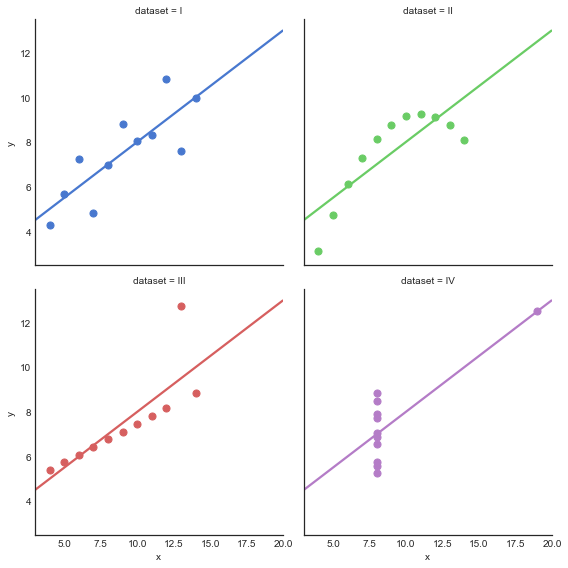

```python
sns.lmplot(x="x", y="y", col="dataset", hue="dataset", data=df,
           col_wrap=2, ci=None, palette="muted", size=4,
           scatter_kws={"s": 50, "alpha": 1})
```

# jointplot()

First we'll select movies released in the 1990s:

```python
geq = movie_df['Year'] >= 1990
leq = movie_df['Year'] <= 1999
subset = movie_df[ geq & leq ]
subset.head()
```

|  | Title | Year | Rating | Votes |
| --- | --- | --- | --- | --- |
| 0 | !Next? | 1994 | 5.4 | 5 |
| 23 | 'N Sync TV | 1998 | 7.5 | 11 |
| 33 | 't Zal je gebeuren... | 1998 | 6.0 | 7 |
| 34 | 't Zonnetje in huis | 1993 | 6.1 | 148 |
| 42 | .COM | 1999 | 3.8 | 5 |

We can draw a scatter plot of movie votes and ratings using the [**`scatter()`**](http://matplotlib.org/examples/shapes_and_collections/scatter_demo.html) function.

```
Text(0,0.5,'Rating')
```

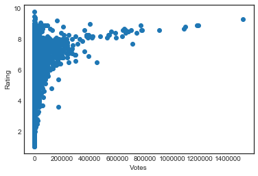

```python
plt.scatter(subset['Votes'], subset['Rating'])
plt.xlabel('Votes')
plt.ylabel('Rating')
```

If there are too many data points we can decrease symbol size, set symbols empty, and make them transparent.

```
Text(0,0.5,'Rating')
```

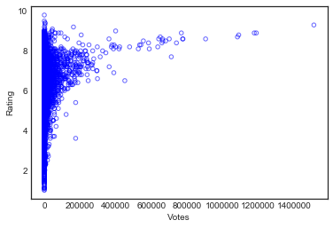

```python
plt.scatter(subset['Votes'], subset['Rating'], s=20, alpha=0.6, facecolors='none', edgecolors='b')
plt.xlabel('Votes')
plt.ylabel('Rating')
```

The number of votes is broadly distributed so we'll set the x axis to log scale.

```
Text(0,0.5,'Rating')
```

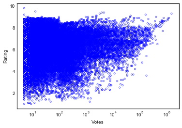

```python
plt.scatter(subset['Votes'], subset['Rating'], s=10, alpha=0.6, facecolors='none', edgecolors='b')
plt.xscale('log')
plt.xlabel('Votes')
plt.ylabel('Rating')
```

We can combine scatter plot with 1D histogram using seaborn's [**`jointplot()`**](http://stanford.edu/~mwaskom/software/seaborn/generated/seaborn.jointplot.html) function.

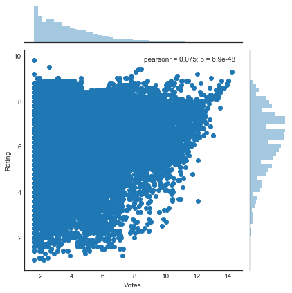

```python
sns.jointplot(np.log(subset['Votes']), subset['Rating'])
```

## Hexbin

Another way of dealing with too many data points is to bin them, which can be done by using [**`jointplot()`**](http://stanford.edu/~mwaskom/software/seaborn/generated/seaborn.jointplot.html) and setting the `kind` parameter.

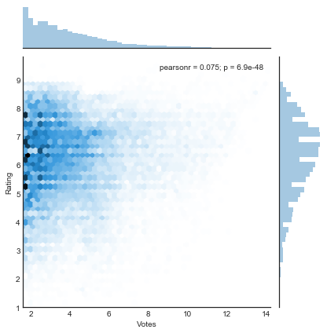

```python
sns.jointplot(np.log(subset['Votes']), subset['Rating'], kind="hex")
```

We can also do 2D KDE using seaborn's [**`kdeplot()`**](https://stanford.edu/~mwaskom/software/seaborn/generated/seaborn.kdeplot.html) function.

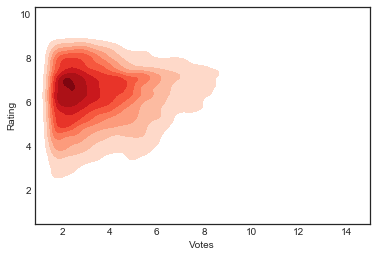

```python
sns.kdeplot(np.log(subset['Votes']), subset['Rating'], cmap="Reds", shade=True, shade_lowest=False)
```

Or by using [**`jointplot()`**](http://stanford.edu/~mwaskom/software/seaborn/generated/seaborn.jointplot.html) and setting the `kind` parameter.

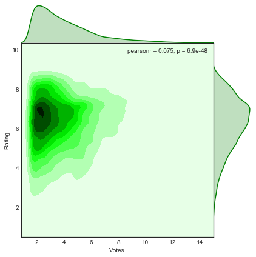

```python
sns.jointplot(np.log(subset['Votes']), subset['Rating'], kind="kde", space=0, color="g")
```